# Week1 debrief

Elliot Teo

22/07/2020

# PICU summary report

## Basline characteristics

No abnormal observations were made prior to induction of anaesthesia. Both animals received vitamin K as usual.

| Pig | Date | Premature_death | Age(h) | Sex | Group | Litter | Body_weight_start | Baseline Neurobehaviour |
| --- | --- | --- | --- | --- | --- | --- | --- | --- |
| 2549 | 2020-07-20 | FALSE | 12 | MALE | TUBE B | 2 | 1.44 | 22 |
| 2550 | 2020-07-20 | TRUE | 12 | MALE | NA | 2 | 1.60 | 22 |

## Brain activity

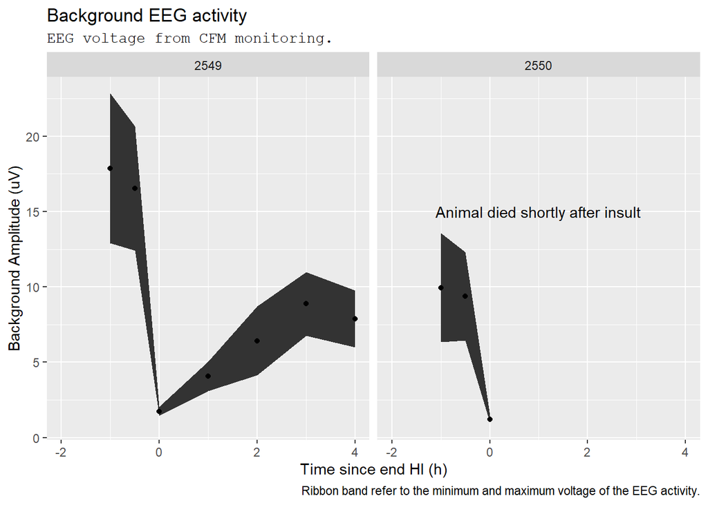

## Cardiovascular response

Piglet 2549 demonstrates typical biphasic response to hypoxia, with a sharp increase following reperfusion. Piglet 2550 did not have a secondary return in heart rate and dies shortly following reperfusion. Insult was ceased at this time however we were unable to resuscitate the animal. 2550 died of cardiac arrest shortly after.

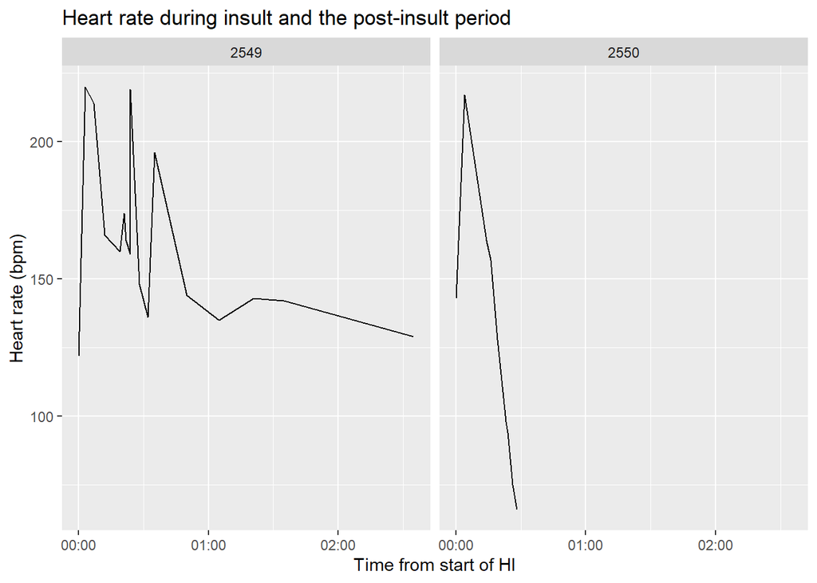

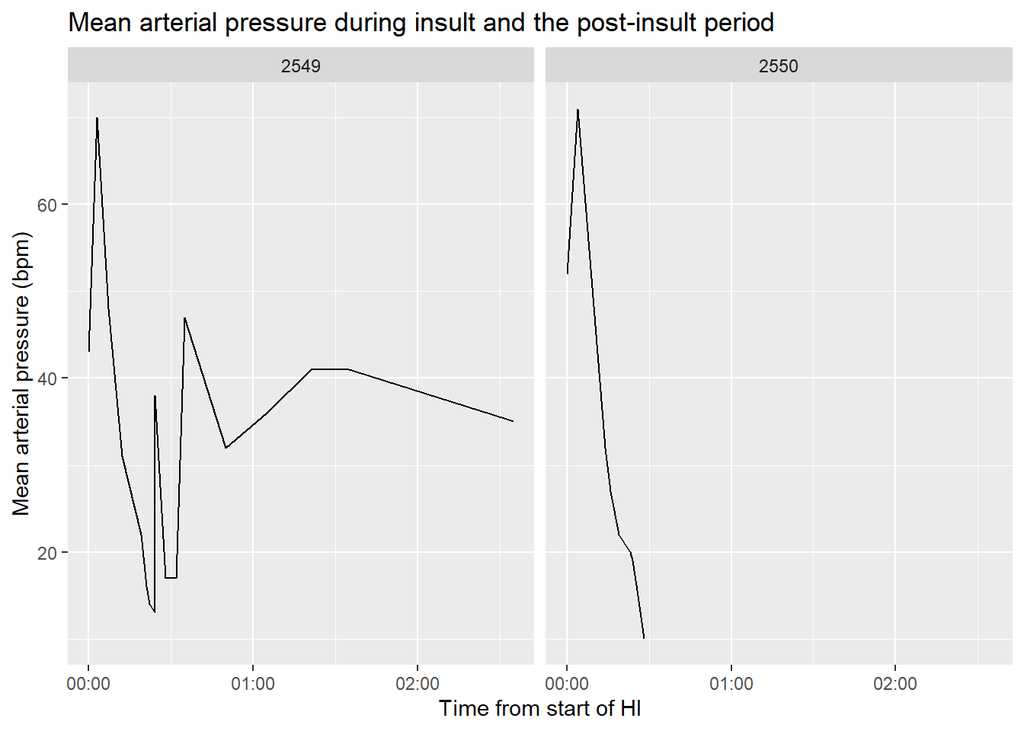

[output not shown]

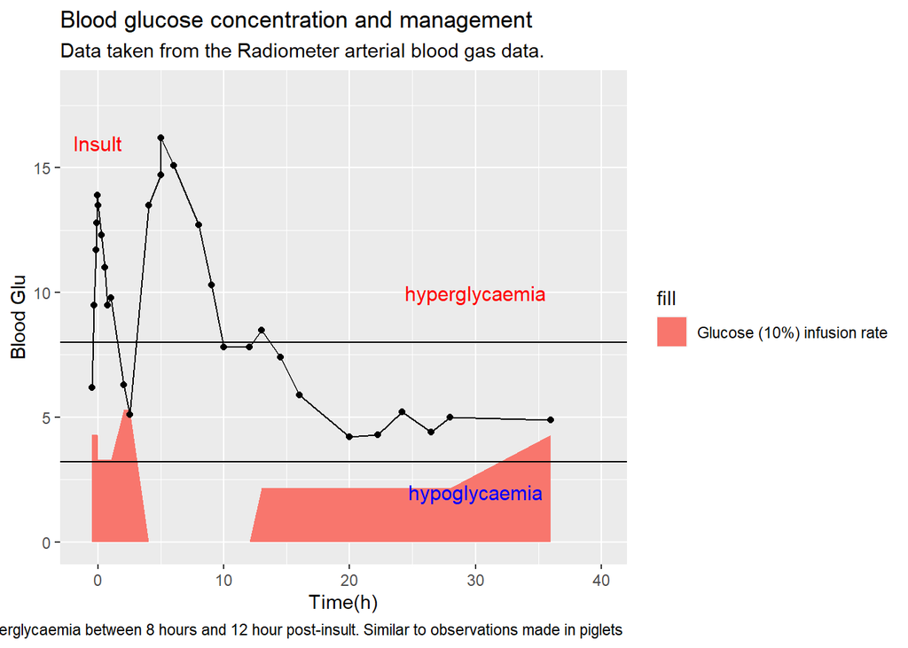

[output not shown]